# PUMP: Estimating Power, MDES, and Sample Size with Multiple Outcomes

Researchers in the social sciences and other fields frequently use randomized controlled trials (RCTs) to determine the impact of an intervention of interest. We introduce the power under multiplicity project (`PUMP`) `R` package as a tool for analysts to estimate statistical power, minimum detectable effect size, and sample size requirements for multi-level RCTs. `PUMP` fills a gap in existing software tools by estimating power when applying a multiple testing procedure to adjust for measuring the impact of a single intervention on multiple outcomes. Current power estimation software does not take into account the use of multiple testing procedures, which can result in inaccurate estimate of power, and limits the different notions of power an analyst may want to consider. The `PUMP` package supports a variety of commonly-used RCT designs and models and multiple testing procedures. In addition to the main functionality of estimating power, minimum detectable effect size, and sample size requirements, the package allows the user to easily explore sensitivity of these quantities to changes in underlying assumptions. In this paper, we first introduce the package, and motivate the problem of multiple testing. Next, we introduce a specific educational experiment as a running example throughout the paper. We then introduce the package functionality, and the simulation-based approach to power estimation employed by the package. Finally, we demonstrate applying `PUMP` to the educational experiment to inform an analyst’s choices.

The `PUMP` `R` package addresses an urgent need among researchers: an open-source software tool to design multi-level randomized controlled trials (RCTs) with adequate statistical power. With this package, researchers can estimate statistical power, minimum detectable effect size (MDES), and needed sample size for multi-level experimental designs, in which units are nested within hierarchical structures such as students nested within schools nested within school districts. The statistical power is calculated for estimating the impact of a single intervention on multiple outcomes. The package uses a frequentist framework of mixed effects regression models, which is currently the prevailing framework for estimating impacts from experiments in education and other social policy research.

To our knowledge, none of the existing software tools for power calculations allow researchers to account for multiple hypothesis tests and the use of a multiple testing procedure (MTP). MTPs adjust $p$-values to reduce the likelihood of spurious findings when researchers are testing for effects on multiple outcomes. This adjustment can result in a substantial change in statistical power, greatly reducing the probability of detecting effects when they do exist. Unfortunately, when designing studies, researchers who plan to test for effects on multiple outcomes and employ MTPs frequently ignore the power implications of the MTPs.

Also, as researchers change their focus from one outcome to multiple outcomes, multiple definitions of statistical power emerge (Chen (2011); Dudoit (2003); Senn and Bretz (2007); T. Westfall Peter H and Wolfinger (2011)). The `PUMP` package allows researchers to consider multiple definitions of power, as some may be most suited for the goals of their study. For example, one might consider *individual power,* the probability of detecting an effect of a particular size (specified by the researcher) or larger for each hypothesis test. Individual power corresponds to how power is defined when there is focus on a single outcome. However, researchers might also consider *$1-$minimal power,* the probability of detecting effects of at least a particular size on at least one outcome. In contrast, one might consider *complete power,* the power to detect effects of at least a particular size on *all* outcomes.

The prevailing default in many studies–-individual power–-may or may not be the most appropriate type of power. If the researcher’s goal is to find statistically significant estimates of effects on most or all primary outcomes of interest, then their power may be much lower than anticipated when multiplicity adjustments are taken into account. On the other hand, if the researcher’s goal is to find statistically significant estimates of effects on at least one or a small proportion of outcomes, their power may be much better than anticipated. In both of these cases, by not accounting for both the challenges and opportunities arising from multiple outcomes, a researcher may find they have wasted resources, either by designing an underpowered study that cannot detect the desired effect sizes, or by designing an overpowered study that had a larger sample size than necessary. We introduce the `PUMP` package to allow for directly answering questions that take multiple outcomes into account, such as:

- How many schools would I need to detect a given effect on at least three of my five outcomes?
- What size effect can I reliably detect on each outcome, given a planned MTP across all my outcomes?
- How would the power to detect a given effect change if only half my outcomes truly had impact?

`PUMP` implements new, rigorously validated methods developed by the authors to estimate statistical power for multiple definitions of power across a wide range of common experimental designs. `PUMP` extends functionality of the popular PowerUp! `R` package (and related tools in the form of a spreadsheet and Shiny application), which compute power or MDES for multi-level RCTs with a single outcome (Dong and Maynard (2013)). For a wide variety of RCT designs with a single outcome, researchers can take advantage of closed-form solutions and numerous power estimation tools. For example, in education and social policy research, see Dong and Maynard (2013); Hedges and Rhoads (2010); Raudenbush et al. (2011); Spybrook et al. (2011). However, closed-form solutions are difficult or impossible to derive when an MTP is applied to a setting with multiple outcomes. Instead, we use a simulation-based approach to achieve estimates of power.

In order to calculate power, the researcher specifies information about the sample size at each level, the minimum detectable effect size for each outcome (the smallest true effect sizes to detect with statistical significance, in units of standard deviations), the level of statistical significance, and parameters of the data generating distribution. An “effect size” generally refers to the standardized mean difference effect size, which “equals the difference in mean outcomes for the treatment group and control group, divided by the standard deviation of outcomes across subjects within experimental groups” (Bloom (2006)). Researchers often use effect sizes to standardize outcomes so that outcomes with different scales can be directly compared.

The package includes three core functions:

- `pump_power()` for calculating power given a experimental design and assumed model, parameters, and minimum detectable effect size.
- `pump_mdes()` for calculating minimum detectable effect size given a target power and sample sizes.
- `pump_sample()` for calculating the required sample size for achieving a given target power for a given minimum detectable effect size.

For any of these core functions, the user begins with two main choices. First, the user chooses the assumed design and model of the RCT. The `PUMP` package covers a range of multi-level designs, up to 3 levels of hierarchy, that researchers typically use in practice, in which research units are nested in hierarchical groups. Our power calculations assume the user will be analyzing these RCTs using frequentist mixed-effects regression models, containing a combination of fixed or random intercepts and treatment impacts at different levels, as we explain in detail in Section~ and in the Supplementary Materials. Second, the user chooses the MTP to be applied. `PUMP` supports 5 common MTPs — Bonferroni, Holm, single-step and step-down versions of Westfall-Young, and Benjamini-Hochberg. After these two main choices, the user must also make a variety of decisions about parameters of the data generating distribution.

The package also includes functions that allow users to easily explore power over a range of possible values of parameters. This exploration encourages the user to determine the sensitivity of estimates to different assumptions. `PUMP` also visually displays results. These additional functions include:

- `pump_power_grid()`, `pump_mdes_grid()`, and `pump_sample_grid()` for calculating the given output over a range of possible parameter values.
- `update()` to re-run an existing calculation with a small number of parameters updated.
- `plot()` on any `PUMP`-generated object to generate plots (including grid outputs).

We illustrate our package using an example of a published RCT that evaluated a secondary school model called Diplomas Now. The Diplomas Now model is designed to increase high school graduation rates and post-secondary readiness. Evaluators conducted a RCT comparing schools who implemented the model to business-as-usual. We refer to this example throughout this paper to illustrate key concepts and to illustrate the application of the `PUMP` package.

The Diplomas Now model, created by three national organizations, Talent Development, City Year, and Communities In Schools, targets underfunded urban middle and high schools with many students who are not performing well academically. The model is designed to be robust enough to transform high-poverty and high-needs middle and high schools attended by many students who fall off the path to high school graduation. Diplomas Now, with MDRC as a partner, was one of the first validation grants awarded as part of the Investing in Innovation (i3) competition administered by the federal Department of Education.

The evaluation focused on three categories of outcomes: Attendance, Behavior, and Course performance, called the “ABC’s,” with multiple measures for each category. In addition, the evaluation measured an overall ABC composite measures of whether a student is above given thresholds on all three categories. This grouping constitutes 12 total outcomes of interest. Evaluating each of the 12 outcomes independently would not be good practice, as the chance of a spurious finding is not well controlled. The authors of the MDRC report pre-identified three of these outcomes as *primary* outcomes before the start of the study in order to reduce the problem of multiple testing. We, by contrast, use this example to illustrate what could be done if there was uncertainty as to what should be the primary outcome. In particular, we illustrate how to conduct a power analysis to plan a study where one uses multiple testing adjustment, rather than predesignation, to account for the multiple outcome problem.

There are different guidelines for how to adjust for groupings of multiple outcomes in education studies. For example, Schochet (2008) recommends organizing primary outcomes into domains, conducting tests on composite domain outcomes, and applying multiplicity corrections to composites across domains. The What Works Clearinghouse applies multiplicity corrections to findings within the same domain rather than across different domains. We do not provide recommendations for which guidelines to follow when investigating impacts on multiple outcomes. Rather, we address the fact that researchers across many domains are increasingly applying MTPs and therefore need to correctly estimate power, MDES and sample size requirements accounting for this choice. In our example, we elect to do a power analysis separately for each of the three outcome groups of the ABC outcomes to control family-wise error rather than overall error. This strategy means we adjust for the number of outcomes within each group independently. For illustration purposes, we focus on one outcome group, attendance, which contains five separate outcomes.

Our motivating example illustrates that researchers are often interested in testing the effectiveness of a single intervention on multiple outcomes. The resulting multiplicity of statistical hypothesis tests can lead to spurious findings of effects. Multiple testing procedures (MTPs) counteract this problem by adjusting $p$-values for effect estimates; generally, $p$-values are adjusted upward to require a higher burden of proof. When not using an MTP, the probability of finding false positives increases, sometimes dramatically, with the number of tests. When using an MTP, this probability is reduced.

First, we remind the reader of how raw, or unadjusted, $p$-values are calculated in this setting, before introducing adjustments due to multiple testing. Consider that a researcher is interested in testing the impact of an intervention on $M$ outcomes. In our running example of the Diplomas Now study, if we had 5 outcomes in the attendance group, we would have $M = 5$. We apply a frequentist hypothesis testing framework, and frame impacts in terms of effect sizes ($ES$). For outcome $m$, we can test a null hypothesis of no effect, $H_{0_m}: ES_m = 0$, against an alternative hypothesis $H_{1_m}: ES_m \neq 0$ for a two-sided tests or $H_{1_m}: ES_m > 0$ or $H_{1_m}: ES_m < 0$ for a one-sided test. A significance test, such as a two- or one-sided $t$-test, would then typically be driven by a test statistic given by
$$\begin{equation}
t_m = \frac{\widehat{ES}_m}{SE(\hat{ES}_m)},
\end{equation}$$
where $SE(\hat{ES}_m)$ is the standard error. A raw $p$-value would then be computed as the probability of being at least as extreme as the one observed, given that the null hypothesis is true. For a two-sided test, the raw $p$-value for test $m$ is $p_m=2*Pr(T_m \geq |t_m|)$. The `PUMP` package also allows for either one-sided or two-sided tests, but we proceed assuming two-sided tests going forward.

When testing a *single* hypothesis under this framework, researchers typically specify $\alpha$, the maximum acceptable probability of making a Type I error. A Type I error is the probability of erroneously rejecting the null hypothesis when it is true. The quantity $\alpha$ is also referred to as the significance level. If $\alpha=0.05$, then the null hypothesis is rejected if the $p$-value is less than $0.05$, and it is concluded that the intervention had an effect because there is less than a $5$% chance that this finding is a false positive.

When one tests *multiple* hypotheses under this framework (such that $M>1$) and one conducts a separate test for each of the hypotheses with $\alpha=0.05$, there is a *greater* than $5\%$ chance of a false positive finding in the study. If the multiple tests are independent, the probability that at least one of the null hypothesis tests will be erroneously rejected is
$$1-Pr(\text{none of the null hypotheses will be erroneously rejected}) = 1-(1-\alpha)^M.$$
Therefore, if researchers are estimating effects on 3 outcomes (and if these outcomes are independent) the probability of at least one false positive finding is $1-(1-0.05)^3=0.14$. If the researchers were instead estimating effects on 5 independent outcomes, the probability of at least one false positive finding rises to $0.23$. This Type I error inflation for independent outcomes demonstrates the crux of the multiple testing problem. In practice, however, the multiple outcomes are usually at least somewhat correlated, which makes the test statistics correlated and reduces the extent of Type I error inflation. Nonetheless, any error inflation can still make it problematic to draw reliable conclusions about the existence of effects above a specified size.

As introduced above, multiple testing procedures (MTPs) adjust $p$-values to counteract the multiple testing problem. We next describe how using a MTP protects against false positives.

Considering multiple outcomes presents both challenges and opportunities. First, we discuss the impact of MTPs on individual power. Recall that the power of an individual hypothesis test is the probability of correctly rejecting a null hypothesis when the effect is at least a specified size. We refer to a setting in which the true impact is at least as large as the desired effect size as a “false null” hypothesis, while a “true null” is a setting in which the true impact is less than the desired effect size. If $p$-values are adjusted upward, one is less likely to reject true nulls, which reduces the probability of Type I errors, or false positive findings. At the same time, MTPs increase the probability of a Type II error, or false negative findings, when the test fails to reject a false null. Individual power is $1 - Pr(\text{Type II error})$, so MTPs have the tradeoff of reducing Type I errors but also reducing individual power.

Next, we consider the impact of multiple outcomes on other definitions of power. Applying an MTP reduces power according to all definitions of power relative to the case when no MTP is applied to adjust $p$-values. However, as discussed previously, having multiple outcomes also allows for a wider variety of definitions of success. Recall that $1-$minimal power is the probability of detecting an effect (of at least a specified size) on at least one outcome. Typically, $1-$minimal power, even after applying a MTP, is higher than individual power for a hypothesis test on a single, pre-specified outcome. Depending on the setting, other definitions of power, such as $1/2$ or $1/3$-minimal power, may or may not have higher power than the power of a single hypothesis test.

The MTPs that are the focus of this paper have three key features that affect statistical power: (1) whether the MTP is a familywise procedure or a false discovery rate procedure; (2) whether the MTP is single-step or stepwise; and (3) whether the MTP takes the correlation between test statistics into account. Below we explain each of these features of MTPs and provide discussion of the new parameter specifications they require when estimating power.

Familywise procedures reframe Type I error as a rate across the entire set or “family” of multiple hypothesis tests. This rate is called the familywise error rate (FWER; Tukey (1953)). The FWER is typically set to the same value as the probability of a Type I error for a single test, e.g., $\alpha$. MTPs that control the FWER at $5\%$ adjust $p$-values in a way that ensures that the probability of at least one Type I error across the entire set of hypothesis tests is no more than $5\%$. The MTPs introduced by Bonferroni (Dunn (1959), Dunn (1961)), Holm (1979), and P. H. Westfall and Young (1993) control the FWER.

MTPs may provide either weak or strong control of the error rate they target. An MTP provides weak control of the FWER or the FDR at level $\alpha$ if the control can only be guaranteed when all nulls are true, e.g. when the effects on all outcomes are zero. An MTP provides strong control of the FWER or FDR at level $\alpha$ if the control is guaranteed when some null hypotheses are true and some are false, e.g. when there may be effects on at least some outcomes. Of course, strong control is preferred.

A second feature of a MTP that affects its statistical power is whether it is a “single-step” or “stepwise” procedure. Single-step procedures adjust each $p$-value independently of the other $p$-values. For example, the Bonferroni MTP multiplies all raw $p$-values by $M$. Therefore, one $p$-value adjustment does not depend on other $p$-value adjustments, only on the number of tests. In contrast, stepwise procedures first order raw $p$-values (or test statistics), and then adjust according to the order of the tests. The adjustments depend on the null hypotheses already rejected in previous steps. For example, the Holm MTP — the stepwise counterpart to the Bonferroni MTP — orders raw $p$-values from smallest to largest. The procedure then multiplies the smallest $p$-value by $M$, the second smallest $p$-value by $M-1$, and so on. The Holm MTP, like most other stepwise procedures, also enforces monotonicity: each adjusted $p$-value is greater than or equal to the previous adjusted $p$-value, and enforces that any $p$-values is not greater than one. Overall, stepwise MTPs allow for less adjustment than single-step MTPs in later steps, and therefore preserve more power (for outcomes in the later steps). The Bonferroni and one of the Westfall-Young MTPs are single-step; the Holm and Benjamini-Hochberg MTPs and the other Westfall-Young MTP are stepwise. Note that stepwise procedures may be “step-down” or “step-up,” referring to whether a procedure begins with the smallest $p$-value, and thus the largest effect size (step-down) or the largest $p$-value (step-up).

Due to the dependencies of adjustments in stepwise MTPs, a new assumption must be considered when estimating power, MDES or sample size under multiplicity: the proportion of outcomes on which there are truly impacts of at least the size of the researchers’ desired ES, or, equivalently, the number of false null hypotheses. There is one scenario in which this assumption does not matter, which is the scenario when one focuses on individual power and uses a single-step MTP. In this case, when adjusting a $p$-value for a single test, the information from other tests is disregarded. For all other scenarios, however, the assumption of the number of false nulls can be an important one.

Researchers may be inclined to assume that there will be effects on all outcomes, as hypotheses of effects probably drive the selection of outcomes in the first place. And when estimating power for a single hypothesis test, power is only defined when a true effect exists. However, if the researchers are incorrect and there turn out not to be effects on all outcomes, the probability of detecting the effects that actually do exist can be diminished, sometimes substantially.

It is important to point out that under the assumption that there are not truly effects on every outcome under study, the definitions of the $d-$minimal powers (e.g., $1-$minimal power, $1/3-$minimal power, etc.) and of complete power become fuzzy. For example, $1/3-$minimal power is defined as the probability of detecting effects (of a specified size or larger) on at least $1/3$ of the total outcomes ($M$), regardless of the number of outcomes with actual effects. That is, $1/3-$minimal power is not defined as the probability of detecting effects among the M outcomes on which the effects truly exist. Therefore, while individual power is defined based on false nulls, the definition of power is loosened here and includes the probability of erroneous rejections of true nulls (which are controlled to occur at no more than 5% for those MTPs that control the FWER). This fuzziness of definition is needed because the researcher would only ever define power based on the total number of tests. Moreover, if the $d-$minimal powers are defined only based on false nulls, then their levels could increase when the proportion of false nulls decreases. Complete power has the same issue. If there are truly only effects on two of the three outcomes, then complete power is not the probability of rejecting just two false null hypotheses. In this case, complete power is undefined.

There is an additional technical note about the calculation of complete power. To calculate complete power, we do not need to adjust the $p$-values, and can instead reject each individual test based on the unadjusted $p$-values. Complete power is the power of the test constructed by whether or not we reject all the null hypotheses. This test was originally introduced as the intersection-union test because the null hypothesis is expressed as a union and the alternative hypothesis is expressed as an intersection (Berger (1982), Berger and Hsu (1996)). Berger (1982) showed that if all the individual tests are level $\alpha$, the intersection-union test is also a level $\alpha$ test. To provide some intuition, we do not need to adjust $p$-values for complete power because it is a special case where we must reject *all* the hypothesis tests. Thus, there is no way for the omnibus test to be rejected by chance because of a favorable configuration (Chen (2011)). For example, consider if we have 4 tests, with 2 false nulls and 2 true nulls. If we consider $3-$minimal power, we just need one of the two true nulls to be rejected by chance alone, and there are two ways for this to occur. For complete power, there is only one way for us to reject all of the nulls. The downside of an intersection-union test is that it is conservative: the FWER is generally less than $\alpha$. For example, if we have two independent tests with Type I error $\alpha$, then if both of the nulls are true, the probability of a Type I error is $\alpha^2$ (Deng, Xu, and Wang 2008).

Finally, a third feature of an MTP that affects its statistical power is whether or not it takes into account the correlation between test statistics. The Bonferroni and Holm procedures strongly control the FWER in all cases, even when the test statistics are correlated, but they adjust $p$-values more than is necessary in that case. Along with the Bonferroni and Holm MTPs, the Benjamin-Hochberg MTP also does not take correlations into account. In contrast, both of the Westfall-Young MTPs rely on the estimation of the joint distribution of test statistics when the complete null hypothesis (that there are not effects on any of the outcomes) is true. This joint distribution of the test statistics is estimated from the study’s data. For example, permutations of the treatment indicator can be used to estimate impacts when the association between treatment status and the outcome is broken. Random permutations of the research group assignments are conducted a large number of times, resulting in a distribution of test statistics under the complete null. Because the actual data are used to generate this null distribution, correlations among the test statistics are captured. Then observed test statistics can be compared with the distribution of test statistics under the complete null hypothesis.

The correlation between test statistics is a parameter a researcher must specify in order to estimate power, MDES or sample size requirements when using an MTP. The $M$ pairwise correlations are equal to the $M$ pairwise correlations between the residuals in the $M$ impact models. If there are no covariates in the impact models or if the $R^2$’s of the covariates are equivalent in all impact models, then the correlations between the test statistics are equal to the correlations between the outcomes. However, having different $R^2$’s across the impact models reduces the correlations between the residuals and therefore between test statistics. Models of outcomes that are highly correlated are more likely to have residuals that are highly correlated because baseline covariates will tend to have similar $R^2$’s. The gaps between the correlations between outcomes and the correlations between residuals — and therefore the test statistics — may be wider for moderately or weakly correlated outcomes. In any case, the upper bounds of correlations between the test statistics are the correlations between the outcomes.

We take an innovative simulation-based approach to estimating power, as introduced in Porter (2018). This approach is then also applied to estimate MDES and sample size. We view simulation as necessary: in order to estimate power for a single outcome, we can often use closed-form algebraic expressions, which are derived from the assumed model. However, with multiple outcomes, finding such expressions can be quite difficult, or even impossible, depending on the multiple testing procedure. In cases where it is possible to find a closed-form expression, we would need to find expressions for every design and model, MTP, and definition of power. Importantly, we would *also* need to find new expressions for any possible number of outcomes, which quickly becomes an intractable problem. Furthermore, in some cases, such as permutation-based procedures like Westfall-Young approaches, a closed-form solution does not exist. To avoid these complexities, we rely on simulation to calculate estimated power. The approach outlined below can estimate power for any scenario.

If we were to rely on a *full* simulation approach, we could use the following method to estimate power. We note that we introduce this full simulation approach to provide intuition, but use a simplified and less computationally intensive approach in the package, as discussed below.

We now describe how to sample from $f(t_1, \dots, t_M)$ directly. First, we assume a particular research design and model. In our example based on the Diplomas Now study, the research design is a $3$-level experiment, with randomization at level $2$. We plan for analyzing our data with a linear regression model with fixed intercepts at the district level, random intercepts at the school level, and a constant treatment effect across schools and districts. As previously, denote $\psi_m$ as the treatment effect for outcome $m$. We express treatment effects in terms of effect sizes:
$$ES_m = \frac{\psi_m}{\sigma_{m}}$$
where $\sigma_{m}$ is the standard deviation of outcome $Y_m$ in the control group. In order to calculate power, we also need the standard error of the impact in effect size units, which we denote as
$$Q_m = SE(\hat{ES}_m).$$
The quantity $Q_m$ is a consequence of the assumed model, the number of units at different levels, the percent of units treated, the assumed $R^2$, and other parameters; our technical appendix shows formulae for $Q_m$ for all the designs and models our package supports. In our Diplomas Now example, $Q_m$ will be a function of the number of students, schools, and districts; the proportion of treated units; the number of student and school covariates; the explanatory power of the student and school covariates; the proportion of variation in the outcome explained by schools and districts; and the amount of impact variation relative to the amount of mean variation. Some parameters, such as the percent of units treated, will generally be known, while others, such as the $R^2$ at different levels, would need to be supplied by the user through either estimation on pilot data or assumptions based on prior knowledge.

Given the effect sizes $ES_m$ and the standard errors $Q_m$, we can determine the distribution of the vector of test statistics. When testing the hypothesis for outcome $m$, the test statistic for a $t$-test is:
$$t_m = \frac{\hat{ES}_m}{\hat{Q}_m}$$
with degrees of freedom $df$, also defined by the assumed model. Under the alternative hypothesis for outcome $m$, $t_m$ has a $t$ distribution with degrees of freedom $df$ and mean $ES_m/Q_m$. Finally, in addition to the parameters above, we also need to choose the correlation matrix between test statistics $\rho$ to sample from the joint distribution of $f(t_1, \dots, t_M)$. With these distributions specified, we can calculate $p$-values.

Note that this approach of simulating test statistics builds on work by Bang (2005), who use simulated test statistics to identify critical values based on the distribution of the maximum test statistics. Their approach produces the same estimates as the approach described here for the single-step Westfall-Young MTP. As an alternative to a simulation-based approach, Chen (2011) derived explicit formulae for $d-$minimal powers of stepwise procedures and for complete power of single-step procedures, but only for $1$, $2$, or $3$ tests. The approach presented here is more generally applicable, as it can be used for all MTPs, for any number of tests, and for all definitions of power discussed in the present paper.

*Remark.* The $p$-value adjustment using Westfall-Young procedures is the most complex correction procedure, so we briefly outline it here. Similar to above, we first explain a full simulation approach, and then discuss our simplification. Under a full simulation approach, we would first generate a single dataset under the joint alternative hypothesis and calculate a set of $M$ observed test statistics. Then, we would permute the single simulated dataset, say $B = 3,000$ times, assuming the joint null hypothesis, and calculate test statistics on each of these permuted datasets. This process generates an empirical distribution of $B$ test statistics under the joint null distribution. Next, we compare the distribution of observed test statistics to the generated distribution of test statistics under the joint null distribution to calculate $p$-values. We would then re-generate a new simulated dataset, and repeat the process. If we were to generate $tnum = 10,000$ datasets under the joint alternative hypothesis, for each of these datasets we generate $B = 3,000$ permuted datasets under the joint null, so we would have to generate $10,000 \times 3,000$ datasets!

When we skip the step of simulating data, then for each iteration $t$ in $1, \dots, tnum$ we first generate a set of $M$ observed test statistics from the joint alternative distribution. Then, we draw $B$ samples of test statistics under the joint null rather than permuting the data $B$ times. Under the null hypothesis, $t_m$ has a $t$ distribution with degrees of freedom $df$ and mean $0$. As before, we then compare the distribution of observed test statistics to the distribution of test statistics under the joint null distribution to calculate $p$-values. Westfall-Young procedures are computationally intensive, so the approach of skipping the simulated data step is particularly helpful here. This approach substantially reduces computational time by drawing test statistics directly rather than permutating the data.

Frequently, a researcher’s main concern with power is calculating either the MDES for each outcome in a given study, or determining the necessary sample size to achieve a target power given a specified set of MDES values. In Diplomas Now, we might want to know what sample sizes we would need to detect at least one significant effect across our outcomes if all the outcomes had a specified effect size (corresponding to $1-$minimal power) and we were planning on using the Holm procedure.

For `pump_mdes()` and `pump_sample()`, the user provides a particular target power, say $80\%$. The method then conducts a stochastic optimization problem to determine a value (of sample size or MDES) that is within a specified tolerance of the target power with high probability. We discuss the algorithm for MDES, although the approach for determining sample size is the same.

The algorithm first determines an initial range of MDES values that likely contain the target MDES. The lower bound is determined by the MDES for an analysis with no adjustment, and the upper bound is determined by the MDES for an analysis with a Bonferroni adjustment, as these provide conservative bounds and can be found using closed-form solutions.

The initial range is calculated using formulae based on the standard errors and degrees of freedom. In particular, from Dong and Maynard (2013), in general the MDES can be estimated as
$$MDES = MT_{df} \times SE / \sigma_{m}$$
where $MT_{df}$ is known as the multiplier and is the sum of two $t$ statistics with degrees of freedom $df$. For one-tailed tests, $MT_{df} = t_{\alpha}^\star + t_{1-\beta}^\star$ where $\alpha$ is the Type I error rate and $\beta$ is the desired power. For two-tailed tests, $MT_{df} = t_{\alpha/2}^\star + t_{1-\beta}^\star$. We do not explain the details of the derivations of the multiplier here; for more details and understanding, see Dong and Maynard (2013) or Bloom (2006). These expressions can be further manipulated to obtain sample size formulae; see the technical appendix for all formula in the package.

Using these formulae we can calculate bounds by manipulating the $\alpha$ and $\beta$ values. To calculate the lower bound, we apply the formula above as given; to calculate the upper bound, we apply the formula using $\alpha/M$ to correspond to a Bonferroni correction. We use the $\beta$ to adjust for the desired power and definition. For example, if we are interested in complete power, we need a larger upper bound than for individual power; in order to have a complete power of $0.8$, we would need each outcome to have an individual power of $\text{0.8}^{(1/M)}$, assuming independence. If we are interested in minimal power, we must have a smaller lower bound; in order to have $1-$minimal power of $0.8$, each outcome needs to have individual power of $1 - (1 - \text{0.8})^{(1/M)}$. We ignore correlation in the setting of the initial bounds; the bounds do not need to be strict, given the adaptive nature of the subsequent search.

Once the initial range is established, we use `pump_power()` with the complete array of design parameters including the correlation between test statistics to obtain rough (using a small `tnum`, or number of simulation trials) estimates of power for five initial values across this range. We then fit a scaled logistic curve to these five points, and identify where the curve crosses the desired power level. After fitting an initial curve, we iterate, repeatedly calculating power for the targeted point and using the result to update the logistic curve model. With each iteration we increase `tnum` to increase precision as we narrow in on the final answer; with each update to our estimated power curve, we weigh the collection of observations by their precisions (determined by corresponding `tnum` value). If a test point achieves the target power to within tolerance, we conduct an additional simulation check using a high number of replicates to verify the proposed answer is within a specified tolerance of the target power; if it is not, we continue the iterative search. The default tolerance is $1\%$, so given a target power of $80\%$, we stop when we find a MDES that gives an estimated power between $79\%$ and $81\%$. In practice, due to the monotonic nature of the logistic functional form, our algorithm generally converges fairly rapidly. However, in certain corner cases the algorithm may fail to converge on a value within tolerance. For more information on applying the search algorithm, see the sample size vignette on CRAN.

We completed extensive validation checks to ensure our power calculation procedures are correct. First, we compared our power estimates in scenarios with only one outcome, $M = 1$, to those from the `PowerUpR` package. Without a multiple testing procedure adjustment, our estimates match. Second, in order to validate our estimates under multiplicity, we followed the full simulation approach outlined above, in Section~. The simulation approach involves generating many iterations of full datasets according to the assumed design and model, calculating $p$-values, and calculating an empirical estimate of power. Using a binomial distribution we constructed Monte Carlo confidence intervals for the power estimates from the full simulation approach. Then, we validated that the `PUMP` estimates fall within these confidence intervals.

A more detailed explanation of the validation procedure can be found in the Appendix, and full validation code and results are in a supplementary github repository pump_validate. For some scenarios, we have some apparent discrepancies from PowerUp, but these result from different modeling choices. For example, for certain models PowerUp assumes the intraclass correlation is zero, while we allow for nonzero values. When there are discrepancies, these are noted in the appendix.

In this section, we outline in detail the choices a user must make when calculating power, MDES, or sample size.

When planning a study, the researcher first has to identify the design of the experiment, including the number of levels, and the level at which randomization occurs. These decisions can be a mix of the realities of the context (e.g., the treatment must be applied at the school level, and students are naturally nested in schools, making for a cluster randomization), or deliberate (e.g., the researcher groups similar schools to block their experiment in an attempt to improve power). Second, based on the design and the inferential goals of the study, the researchers chooses an assumed model, including whether intercepts and treatment effects should be treated as constant, fixed, or random. For the same experimental design, the analyst can sometimes choose from a variety of possible models, and these two decisions should be kept conceptually separated from each other.

*The design.* The `PUMP` package supports designs with one, two, or three levels, with randomization occurring at any level. For example, a design with two levels and randomization at level one is a blocked design (or equivalently a multisite experiment), where level two forms the blocks (blocks being groups of units, some of which are treated and some not). Ideally, the blocks in a trial will be groups of relatively homogenous units, but frequently they are a consequence of the units being studied (e.g., evaluations of college supports, with students, the units, nested in colleges, the blocks). A design with two levels and randomization at level two is commonly called a cluster design (e.g., a collection of schools, with treatment applied to a subset of the schools, with outcomes at the student level); here the schools are the clusters, with a cluster being a collection of units which is entirely treated or entirely not. We can have both blocking and clustering; for example if we have a series of cluster-randomized experiments within different school districts, ; this would be a blocked (by district), cluster-randomized experiment.

*The model.* Given a design, the researcher can select a model via a few modeling choices. In particular the researcher has to decide about the intercepts and the treatment impacts:

- Whether level 2 and level 3 intercepts are:
  - fixed: we have a separate intercept for each unit.
  - random: we have a separate intercept for each unit as above, but model the collection of intercepts as Normally distributed, allowing for partial pooling.
- Whether level 2 and level 3 treatment effects are:
  - constant: we model all units in a level as having the same single average impact.
  - fixed: we allow each block or cluster within a level to have its own individual estimated impact (we can only do this if we have treated and control units within said block or cluster).
  - random: we allow variation as with fixed, but model the collection of treatment impacts as Normally distributed around a grand mean mean impact. This is implicitly allowing for the sample as being representative of a larger super-population, in terms of treatment impact estimation.

The supported multiple testing procedures were covered in more detail in Section~. Here we provide a review of the list of multiple testing procedures supported by the `PUMP` package is:

- *Bonferroni*: adjusts $p$-values by multiplying them by $M$ to ensure strong control of the FWER. Bonferroni is a simple procedure, but the most conservative.
- *Holm*: a step-down version of Bonferroni. Starting from smallest to largest, $p$-values are sequentially adjusted by different multipliers. Holm is less conservative than Bonferroni for larger $p$-values.
- *Benjamini-Hochberg*: A sequential, step-up procedure that controls the FDR. Using the BH method, only null hypotheses with $p$-values below a certain threshold are rejected, where the threshold is determined by the number of tests and the level $\alpha$.
- *Single-step Westfall-Young*: A permutation-based procedure for controlling the FWER, which directly takes into account the joint correlation structure of the outcomes. In the single-step approach, all outcomes are adjusted by using the permuted distribution of the minimum $p$-value. Although Westfall-Young procedures are less conservative while still protecting against false discoveries, they are computationally very intensive.
- *Step-down Westfall-Young*: A similar approach to the single-step procedure, except that outcomes are adjusted sequentially from smallest to largest according to the permuted distributions of the corresponding sequential $p$-values.

For a more detailed explanation of each MTP, see Appendix A of Porter (2018).

The table below shows the parameters that influence $Q_m$ formulae for different designs and models.

| Parameter | Description |
| --- | --- |
| nbar | the harmonic mean of the number of level 1 units per level 2 unit (students per school) |
| J | the number of level 2 units (schools) |
| K | the number of level 3 units (district) |
| Tbar | the proportion of units that are assigned to the treatment |
| numCovar.1 | number of Level 1 (individual) covariates |
| numCovar.2 | number of Level 2 (school) covariates |
| numCovar.3 | number of Level 3 (district) covariates |
| R2.1 | percent of variation explained by Level 1 covariates |
| R2.2 | percent of variation explained by Level 2 covariates |
| R2.3 | percent of variation explained by Level 3 covariates |
| ICC.2 | level 2 intraclass correlation |
| ICC.3 | level 3 intraclass correlation |
| omega.2 | ratio of variance of level 2 average impacts to variance of level 2 random intercepts |
| omega.3 | ratio of variance of level 3 average impacts to variance of level 3 random intercepts |

A few parameters warrant more explanation.

- The quantity $\text{ICC}$ is the Intraclass Correlation, and gives a measure of variation at different levels of the model. For each outcome, the ICC for each level is defined as the ratio of the variance at that level divided by the overall variance of the individual outcomes. The ICC is for the unconditional model, and therefore includes the variation due to covariates.
- For each outcome, the quantity omega ($\omega$) for each level is the ratio between impact variation at that level and mean variation at that level. It is a measure of treatment impact heterogeneity.
- The $R^2$ expressions are the percent of variation at a particular level predicted by covariates specific to that level. For simplicity we assume covariates at a level are group mean centered, so only covariates at a particular level explain variance at that level.

For precise formulae of these expressions, see the Supplementary Materials, which outlines the assumed data-generating process, and the resulting expressions for $\text{ICC}$, $\omega$, and $R^2$.

In addition to design parameters, there are additional parameters that control the precision of the power estimates themselves:

- $tnum$ is the number of test statistics generated in order to estimate power. A larger number of test statistics results in greater computation time, but also a more precise estimate of power. (Note that the `pump_mdes()` and `pump_sample()` have multiple `tnum` parameters controlling the precision of the search).
- $B$ is the number of Westfall-Young permutations. Again, there is a tradeoff between precision and computation time.

In this section, we illustrate how to use the `PUMP` package, using our example motivated by the Diplomas Now study. Given the study’s design, we ask a natural initial question: What size of impact could we reasonably detect after using an MTP to adjust $p$-values to account for our multiple outcomes?

To conduct power, MDES, and sample size calculations, we first must specify the design, model, and level of statistical significance. We must also must specify parameters of the data generating distribution (e.g., expected relationships between covariates, outcomes, and units in the study) that match the design and model. All of these numbers have to be determined given resource limitations, or estimated using prior knowledge, pilot studies, or other sources of information. We also must specify the sample sizes at each level. Our experiment has students nested in schools nested in randomization blocks that are a function of school type and district. We next discuss selection of all needed design parameters and modeling choices. For further discussion of selecting these parameters see, for example, see Bloom (2006), Dong and Maynard (2013) and Porter (2018).

*Analytic model.* We first need to specify how we will analyze our data; this choice can also determine which design parameters we will need to specify. Following the original Diplomas Now report, we plan on using a multi-level model (a common choice for cluster randomized experiments, and especially common in education) with fixed effects at level three, a random intercept at level two, and a single treatment coefficient. We represent this model as “m3fc2rc.” The “3fc” means we are including block fixed effects, and not modeling any treatment impact variation at level three. The “2rc” means random intercept and no modeled variation of treatment within each block (the “c” is for “constant”). We note that the Diplomas Now report authors call their model a “two-level” model, but this is not quite aligned with the language of this package. In particular, fixed effects included at level two are actually accounting for variation at level three; we therefore identify their model as a three-level model with fixed effects at level three.

*ICCs.* We also need a measure of where variation occurs: the individual, the school, or the randomization block level. We capture this with Intraclass Correlation Coefficients (ICCs), one for level two and one for level three. ICC measures specify overall variation in outcome across levels: e.g., do we see relatively homogeneous students within schools that are quite different, or are the schools generally the same with substantial variation within them? We typically would obtain ICCs from pilot data or external reports on similar data. We here specify a level-two ICC of 0.05, and a level-three ICC of 0.40. We set a relatively high level three ICC to capture the hoped-for purpose of blocking as a means of isolating variation; in particular we might imagine attendance changes markedly between middle and high school as well as across schools.

*Impact variation.* We next need to specify the assumed degree of treatment impact variation. We allow treatment variation across school type and district by setting omega.3 to 0.50 (a substantial amount). While most power analyses would assume no variation, we do here for illustration.

*Correlation of outcomes.* We finally need to specify the number and relationship among our outcomes and associated test-statistics. For illustration, we select attendance as our outcome group. We assume we have five different attendance measures. The main decision regarding outcomes is the correlation of our test statistics. As a rough proxy, we use the correlation of the outcomes at the level of randomization; in our case this would be the correlation of school-average attendance within block. We believe the attendance measures would be fairly related, so we select `rho = 0.40` for all pairs of outcomes. This value is an estimate, and we strongly encourage exploration of different values of this correlation choice as a sensitivity check for any conducted analysis. Selecting a candidate rho is difficult, and will be new for those only familiar with power analyses of single outcomes; we need to more research in the field, both empirical and theoretical, to further guide this choice.

If the information were available, we could specify different values for the design parameters such as the $R^2$s and $ICC$s for each outcome, if we thought they had different characteristics; for simplicity we do not do this here. The `PUMP` package also allows specifying different pairwise correlations between the test statistics of the different outcomes via a matrix of $\rho$s rather than a single $\rho$; also for simplicity, we do not do that here.

Once we have established initial values for all needed parameters, we first conduct a baseline calculation, and then explore how MDES or other quantities change as these parameters change.

We now have an initial planned design, with a set number of schools and students. But is this a large enough experiment to reliably detect reasonably sized effects? To answer this question we calculate the minimal detectable effect size (MDES), given our planned analytic strategy, for our outcomes.

To identify the MDES of a given setting we use the `pump_mdes` method, which conducts a search for a MDES that achieves a target level of power. The MDES depends on all the design and model parameters discussed above, but also depends on the type of power and target level of power we are interested in. For example, we can ask what size effect can we reliably detect on our first outcome, after multiplicity adjustment? Or, we might ask what size effects would we need across our five outcomes to reliably detect an impact on at least one of them? We do this by specifying the type (`power.definition`) and desired power (`target.power`).

Here, for example, we find the MDES if we want an 80% chance of detecting an impact on our first outcome when using the Holm procedure:

```r
m <- pump_mdes(
            design = "d3.2_m3fc2rc", # choice of design and analysis strategy
            MTP = "Holm", # multiple testing procedure
            target.power = 0.80, # desired power
            power.definition = "D1indiv", # power type
            M = 5, # number of outcomes
            J = 3, # number of schools/block
            K = 21, # number RA blocks
            nbar = 258, # average number of students per school
            Tbar = 0.50, # prop Tx
            alpha = 0.05, # significance level
            numCovar.1 = 5, numCovar.2 = 3, # number of covariates per level
            R2.1 = 0.1, R2.2 = 0.7, # Explanatory power of covariates for each level
            ICC.2 = 0.05, ICC.3 = 0.4, # Intraclass correlation coefficients
            omega.3 = 0.50, # Amount of treatment variation at level 3.
            rho = 0.4 ) # how correlated outcomes are
```

The results are easily made into a nice table via `knitr`’s `kable()` command:

| MTP | Adjusted.MDES | D1indiv.power |
| --- | --- | --- |
| Holm | 0.1 | 0.79 |

The answers `pump_mdes()` gives are approximate as we are calculating them via monte carlo simulation. To control accuracy, we can specify a tolerance (`tol`) of how close the estimated power needs to be to the desired target along with the number of iterations in the search sequence (via `start.tnum`, `max.tnum`, and `final.tnum`). The search will stop when the estimated power is within `tol` of `target.power`, as estimated by `final.tnum` iterations. Lower tolerance and higher `tnum` values will give more exact results (and take more computational time).

Changing the type of power is straightforward: for example, to identify the MDES for $1-$minimal power (i.e., what effect do we have to assume across all observations such that we will find at least one significant result with 80% power?), we simply update our result with our new power definition:

```r
m2 <- update( m, power.definition = "min1" )
kable(m2, digits = 2)
```

| MTP | Adjusted.MDES | min1.power |
| --- | --- | --- |
| Holm | 0.08 | 0.8 |

When estimating power for multiple outcomes, it is important to consider cases where some of the outcomes in fact have null, or very small, effects, to hedge against circumstances such as one of the outcomes not being well measured. One way to to do this here is to assume two of our outcomes have no effect; the `numZero` parameter allows for this as follows:

```r
m3 <- update( m2, numZero = 2 )
kable(m3, digits = 2)
```

| MTP | Adjusted.MDES | min1.power |
| --- | --- | --- |
| Holm | 0.09 | 0.79 |

The MDES goes up, as expected.

The MDES calculator tells us what we can detect given a specific design. We might instead want to ask how much larger our design would need to be in order to achieve a desired MDES. In particular, we might want to determine the needed number of students per school, the number of schools, or the number of blocks needed to detect an effect of a given size. The `pump_sample` method will search over any one of these, as requested.

Assuming we have three schools per block, we first calculate how many blocks we would need to achieve a MDES of 0.10 for $1-$minimal power (this answer the question of how big of an experiment do we need in order to have an 80% chance of finding at least one outcome significant, if all outcomes had a true effect size of 0.10).

```r
smp <- pump_sample(
  design = "d3.2_m3fc2rc",
  MTP = "Holm",
  typesample = "K",
  target.power = 0.80, power.definition = "min1", tol = 0.01,
  MDES = 0.10, M = 5, nbar = 258, J = 3,
  Tbar = 0.50, alpha = 0.05, numCovar.1 = 5, numCovar.2 = 3,
  R2.1 = 0.1, R2.2 = 0.7, ICC.2 = 0.05, ICC.3 = 0.40, rho = 0.4 )
```

| MTP | Sample.type | Sample.size | min1.power |
| --- | --- | --- | --- |
| Holm | K | 15 | 0.80125 |

We recommend checking MDES and sample-size calculators, as the estimation error combined with the stochastic search can give results a bit off the target in some cases. A check is easy to do; simply run the found design through `pump_power()`, which directly calculates power for a given scenario, to see if we recover our originally targeted power (we can use `update()` and set the type to `power` to pass all the design parameters automatically). When we do this, we can also increase the number of iterations to get more precise estimates of power, as well:

```r
p_check <- update( smp, type = "power", tnum = 100000 )
print(p_check)
```

```
#> power result: d3.2_m3fc2rc design with 5 outcomes
#>   MTP D1indiv D2indiv D3indiv D4indiv D5indiv indiv.mean    min1    min2
#>  None 0.70098 0.70100 0.70148 0.69981 0.70128   0.700910      NA      NA
#>  Holm 0.52948 0.52737 0.52940 0.52698 0.52716   0.528078 0.81035 0.64653
#>     min3   min4 complete
#>       NA     NA       NA
#>  0.50931 0.3918  0.32685
#>  0.000 <= SE <= 0.001
```

When calculating power directly, we get power for all the implemented definitions of power applicable to the design. In the above, the first five columns are the powers for rejecting each of the five outcomes—they are (up to simulation error) the same since we are assuming the same MDES and other design parameters for each. The `indiv.mean` is the mean individual power across all outcomes. The first row is power without adjustment, and the second row has our power with the listed $p$-value adjustment.

The next columns show different multi-outcome definitions of power. In particular, `min1` and `min2` show the chance of rejecting at least one or two hypotheses, respectively. The `complete` column shows the power to reject all hypotheses; it is only defined if all outcomes are specified to have a non-zero effect.

We can also plot the resulting power object, comparing the different MTPs and definitions of power.

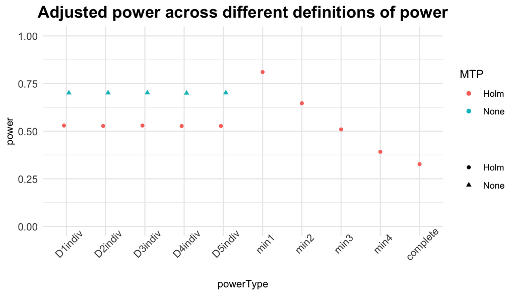

```r
plot( p_check )
```

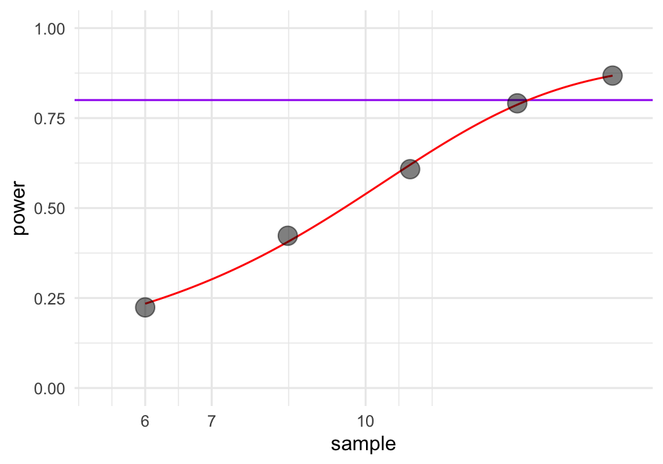

```r
plot_power_curve( smp )
```

The package works with a range of multiple testing procedures and a range of modeling options. In the next two sections we show how to compare these within a given experimental design.

It is easy to rerun the above using the Westfall-Young Stepdown procedure (this procedure is much more computationally intensive to run), or other procedures of interest. Alternatively, simply provide a list of procedures you wish to compare. If you provide a list, the package will re-run the power calculator for each item on the list; this can make the overall call computationally intensive. Here we obtain power for our scenario using Bonferroni, Holm and Westfall-Young adjustments:

```r
p2 <- update( p_check, MTP = c("Bonferroni", "Holm", "WY-SD"), tnum = 10000 )
print( p2 )
```

```
#> power result: d3.2_m3fc2rc design with 5 outcomes
#>         MTP D1indiv D2indiv D3indiv D4indiv D5indiv indiv.mean   min1   min2
#>        None  0.6963  0.6978  0.6879  0.7033  0.6997    0.69700     NA     NA
#>  Bonferroni  0.4262  0.4202  0.4176  0.4258  0.4275    0.42346 0.8080 0.5980
#>        Holm  0.5204  0.5233  0.5213  0.5183  0.5175    0.52016 0.8056 0.6349
#>       WY-SD  0.5354  0.5413  0.5387  0.5457  0.5378    0.53978 0.8242 0.6632
#>    min3   min4 complete
#>      NA     NA       NA
#>  0.3980 0.2248   0.3245
#>  0.4969 0.3847   0.3206
#>  0.5280 0.4013   0.3233
#>  0.001 <= SE <= 0.002
```

There are usually a range of modeling choices one might bring to a given experimental design. For example, for multisite experiments (“d2.1” designs), Miratrix and Henderson (2020, forthcoming) identify 15 different estimation strategies. Different choices can imply different targeted estimands, which in turn can impact power. In particular, methods that target superpopulation averages versus finite sample averages will generally have lower power if there is treatment impact variation.

In `PUMP` these choices are specified by different `design` arguments. For our context, for example, we could use a random effects model at level three instead of a fixed effects model, setting `design = "d3.2_m3rr2rc"` instead of `"d3.2_m3fc2rc"`; this would target a superpopulation average, viewing the blocks as a random sample, versus a finite population where the blocks are considered fixed.

Random effects models allow for level three covariates, which we would need to specify via `numCovar.3` and `R2.3` to capture how many there are and how predictive they are:

```r
p3 <- update( p_check, design = "d3.2_m3rr2rc", numCovar.3 = 3, R2.3 = 0.40 )
print( p3 )
```

```
#> power result: d3.2_m3rr2rc design with 5 outcomes
#>   MTP D1indiv D2indiv D3indiv D4indiv D5indiv indiv.mean    min1    min2
#>  None 0.66570 0.66366 0.66246 0.66345 0.66378   0.663810      NA      NA
#>  Holm 0.44683 0.44670 0.44587 0.44580 0.44647   0.446334 0.72916 0.54557
#>     min3    min4 complete
#>       NA      NA       NA
#>  0.41563 0.31462   0.2827
#>  0.001 <= SE <= 0.001
```

Given the above, we might wonder how power shifts if we change our design parameters. For some discussion of what parameters will affect power more generally, see Dong and Maynard (2013). The key insight is that power is a function of only a few summarizing elements: the individual-level standard errors, the degrees of freedom, and the correlation structure of the test statistics. Once we have these elements, regardless of the design, we can proceed.

Within the pump package we have two general ways of exploring design sensitivity. The first is with `update()`, which allows for quickly generating a single alternate scenario. To explore sensitivity to different design parameters more systematically, use the `grid()` functions, which calculate power, mdes, and sample size for all combinations of a set of passed parameter values. The main difference between the two approaches is the `update()` approach allows for different values of a parameter for the different outcomes. The `grid` approach is more limited in this regard, and assumes the same parameter value across different outcomes. However, the `grid` function powerful tool for systematically exploring many possible combinations, while `update()` only allows the user to explore one value at a time.

We first illustrate the `update()` approach, and then turn to illustrating `grid()` across three common areas of exploration: Intraclass Correlation Coefficients (ICCs), the correlation of test statistics, and the assumed number of non-zero effects. The last two are particularly important for multiple outcome contexts.

Update allows for a quick change of some of the set of parameters used in a prior call; we saw `update()` used several times above. As a further example, here we examine what happens if the ICCs are more equally split across levels two and three:

```r
p_b <- update( p_check, ICC.2 = 0.20, ICC.3 = 0.25 )
print( p_b )
```

```
#> power result: d3.2_m3fc2rc design with 5 outcomes
#>   MTP D1indiv D2indiv D3indiv D4indiv D5indiv indiv.mean    min1    min2
#>  None 0.24591 0.24635 0.24662 0.24762 0.24707   0.246714      NA      NA
#>  Holm 0.09919 0.09984 0.10054 0.10061 0.09904   0.099844 0.27088 0.11833
#>     min3    min4 complete
#>       NA      NA       NA
#>  0.06043 0.03267   0.0253
#>  0.000 <= SE <= 0.001
```

We immediately see that our assumption of substantial variation in level three matters a great deal for power.

When calculating power for a given scenario, it is also easy to vary many of our design parameters by outcome. For example, if we thought we had better predictive covariates for our second outcome, we might try:

```r
p_d = update( p_check,
            R2.1 = c( 0.1, 0.3, 0.1, 0.2, 0.2 ),
            R2.2 = c( 0.4, 0.8, 0.3, 0.2, 0.2 ),
            omega.3 = c( 0.2, 0.4, 0.3, 0.2, 0.2 ) )
print( p_d )
```

```
#> power result: d3.2_m3fc2rc design with 5 outcomes
#>   MTP D1indiv D2indiv D3indiv D4indiv D5indiv indiv.mean    min1    min2
#>  None 0.43021 0.85342 0.38059 0.34139 0.34039    0.46920      NA      NA
#>  Holm 0.24101 0.65224 0.20898 0.18584 0.18613    0.29484 0.71072 0.37171
#>     min3    min4 complete
#>       NA      NA       NA
#>  0.20742 0.11878  0.08438
#>  0.000 <= SE <= 0.001
```

Notice how the individual powers are heavily impacted. The $d$-minimal powers naturally take the varying outcomes into account as we are calculating a joint distribution of test statistics that will have the correct marginal distributions based on these different design parameter values.

After several `update()`s, we may lose track of where we are; to find out, we can always check details with `print_design()` or `summary()`:

```r
summary(p_d)
```

```
#> power result: d3.2_m3fc2rc design with 5 outcomes
#>   MDES vector: 0.1, 0.1, 0.1, 0.1, 0.1
#>   nbar: 258  J: 3    K: 15   Tbar: 0.5
#>   alpha: 0.05
#>   Level:
#>     1: R2: 0.1 / 0.3 / 0.1 / 0.2 / 0.2 (5 covariate)
#>     2: R2: 0.4 / 0.8 / 0.3 / 0.2 / 0.2 (3 covariate) ICC: 0.05   omega: 0
#>     3:   fixed effects    rho = 0.4
#>   MTP D1indiv D2indiv D3indiv D4indiv D5indiv indiv.mean    min1    min2
#>  None 0.43021 0.85342 0.38059 0.34139 0.34039    0.46920      NA      NA
#>  Holm 0.24101 0.65224 0.20898 0.18584 0.18613    0.29484 0.71072 0.37171
#>     min3    min4 complete
#>       NA      NA       NA
#>  0.20742 0.11878  0.08438
#>  0.000 <= SE <= 0.001
#>  (tnum = 100000)
```

Using update allows for targeted comparison of major choices, but if we are interested in how power changes across a range of options, we can do this more systematically with the `grid()` functions, as we do next.

We above saw that the ICC does impact power considerably. We next extend this evaluation by exploring a range of options for both level two and three ICCs, so we can assess whether our power is sufficient across a set of plausible values. The `update_grid()` call makes this straightforward: we pass our baseline scenario along with lists of parameters to additionally explore:

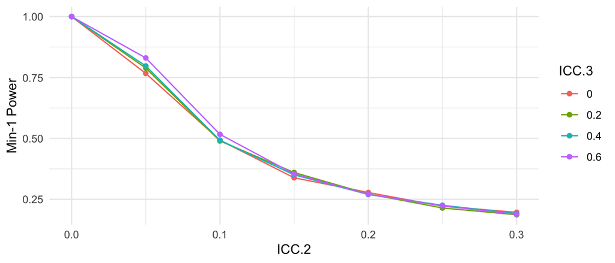

```r
grid <- update_grid( p_check,
            ICC.2 = seq( 0, 0.3, 0.05 ),
            ICC.3 = seq( 0, 0.60, 0.20 ),
            tnum = 5000 )

grid$ICC.3 = as.factor( grid$ICC.3 )
grid = filter( grid, MTP == "Holm" )
ggplot( grid, aes( ICC.2, min1, group = ICC.3, col = ICC.3 ) ) +
    geom_line() + geom_point() +
    labs( y = "Min-1 Power" )
```

We see that higher ICC.2 radically reduces power to detect anything and ICC.3 does little. To understand why, we turn to our standard error formula for this design and model:
$$\begin{aligned}
SE( \hat{\tau} ) = \sqrt{
\frac{\text{ICC}_{2}(1 - R^2_{2})}{\bar{T}(1 - \bar{T}) JK} +
\frac{(1-\text{ICC}_{2} - \text{ICC}_{3})(1-R^2_{1})}{\bar{T}(1 - \bar{T}) J K\bar{n}} } .
\end{aligned}$$
In the above, the $\bar{n} = 258$ students per group makes the second term very small compared to the first regardless of the ICC.3 value. The first term, however, is a direct scaling of ICC.2; changing it will change the standard error, and therefore power, a lot. All provided designs and models implemented in the package are discussed, along with corresponding formula such as these, in our technical supplement accompanying this paper and package.

For grid searches we recommend reducing the number of permutations (here to 5000 via `tnum`) to speed up computation. As `tnum` shrinks, we will get increasingly rough estimates of power, but even these rough estimates can help us determine trends.

The `grid()` functions provide easy and direct ways of exploring how power changes as a function of the design parameters. We note, however, that in order to keep syntax simple, they do not allow different design parameters, including MDES, by outcome. This is to keep package syntax simpler. When faced with contexts where it is believed that these parameters do vary, we recommend using average values for the broader searches, and then double-checking a small set of potential final designs with the `pump_power()` method.

The correlation of test statistics, $\rho$, is a critical parameter for how power will play out across the multiple tests. For example, with Westfall-Young, we saw that the correlation can improve our individual power, as compared to Bonferroni. We might not know what will happen to $2-$minimal power, however: on one hand, correlated statistics make individual adjustment less severe, and on the other correlation means we succeed or fail all together. We can explore this question relatively easily by letting `rho` vary as so:

```r
grid <- update_grid( p_check,
            MTP = c( "Bonferroni", "WY-SS" ),
            rho = c( 0, 0.15, 0.3, 0.45, 0.6 ),
            tnum = 500,
            B = 10000 )
```

We then plot our results.

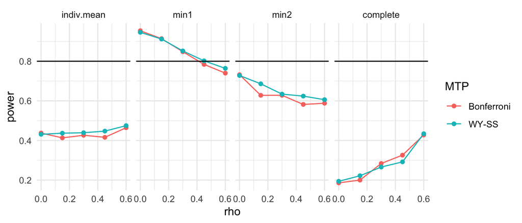

```r
gridL = filter( grid, MTP != "None" ) %>%
  pivot_longer( cols = c(indiv.mean, min1, min2, complete),
                names_to = "definition", values_to = "power" ) %>%
  mutate( definition = factor( definition,
                            levels = c("indiv.mean", "min1", "min2", "complete" ) ) )

ggplot( gridL, aes( rho, power, col=MTP ) ) +
  facet_grid( . ~ definition ) +
  geom_line() + geom_point() +
  geom_hline( yintercept =0.80 ) + theme_minimal()
```

We finally explore varying the number of outcomes with no effects. This exploration is an important way to hedge a design against the possibility that some number of the identified outcomes are measured poorly, or are simply not impacted by treatment. We use a grid search, varying the number of outcomes that have no treatment impact via the `numZero` design parameter:

```r
grid <- update_grid( p_check,
            numZero = 0:4,
            M = 5 )
```

We then can make a plot as we did above:

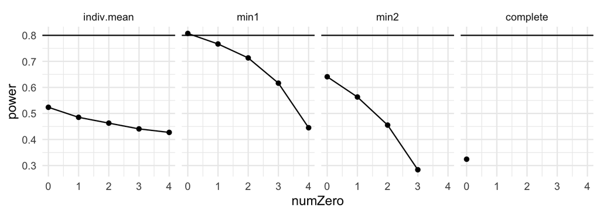

There are other ways of exploring the impact of weak or null effects on some outcomes. In particular, the `pump_power()` and `pump_sample()` methods allow the researcher to provide an MDES vector with different values for each outcome, including 0s for some outcomes. The `grid()` functions, by contrast, take a single MDES value for the non-null outcomes, with a separate specification of how many of the outcomes are 0. (This single value plus `numZero` parameter also works with `pump_power()` if desired.)

We introduce the power under multiplicity project (`PUMP`) `R` package, which estimates power for multi-level randomized control trials with multiple outcomes. `PUMP` allows users to estimate power, MDES, and sample size requirements for a wide variety of commonly used RCT designs and models across different definitions of power and applying different MTPs. The functionality of `PUMP` fills an important gap, as existing tools do not allow researchers to conduct power, MDES or sample size calculations when applying a MTP.

The main advantage of the `PUMP` package is to provide easily accessible estimation procedures so that users can properly account for power when making adjustments for multiple hypothesis testing. However, one of the additional strengths of the package is the ease with which a user can explore the impact of different designs, models, and assumptions on power, MDES or sample size. Even if a user is only interested in a single outcome, `PUMP` provides useful functionality for more robust power calculations. A user can and should try a range of parameter values to determine the sensitivity of the power of their study to different assumptions; this package simplifies that process.

We acknowledge the Diplomas Now team. Development of this package was supported by a grant from the Institute for Education Sciences (R305D170030). We would like to thank members of the Harvard CARES lab for their feedback on the manuscript.

Bang, Jung, H. 2005. “Sample Size Calculation for Simulation-Based Mulitple-Testing Procedures.” Journal Article. *Journal of Biopharmaceutical Statistics* 15: 957–67.

Bates, Douglas, Martin Mächler, Ben Bolker, and Steve Walker. 2015. “Fitting Linear Mixed-Effects Models Using lme4.” *Journal of Statistical Software* 67 (1): 1–48. https://doi.org/10.18637/jss.v067.i01.

Benjamini, & Hochberg, Y. 1995. “Controlling the False Discovery Rate: A Practical and Powerful Approach to Multiple Testing.” *Journal of the Royal Statistical Society: Series B* 57: 289–300.

Berger, Roger L. 1982. “Multiparameter Hypothesis Testing and Acceptance Sampling.” Journal Article. *Technometrics* 24 (4): 295–300.

Berger, Roger L., and Jason C. Hsu. 1996. “Bioequivalence Trials, Intersection–Union Tests and Equivalence Confidence Sets.” Journal Article. *Statistical Science* 11 (4): 283–319.

Bloom, Howard S. 2006. “The Core Analytics of Randomized Experiments for Social Research.” Government Document. MDRC.

Chen, Luo, J. 2011. “On Power and Sample Size Computation for Multiple Testing Procedures.” Journal Article. *Computational Statistics and Data Analysis* 55: 110–22.

Corrin W., Rosen, Sepanik S. 2016. “Addressing Early Warning Indicators: Interim Impact Findings from the Investing in Innovation (I3) Evaluation of Diplomas Now.” Government Document. MDRC.

Deng, Xutao, Jun Xu, and Charles Wang. 2008. “Improving the Power for Detecting Overlapping Genes from Multiple DNA Microarray-Derived Gene Lists.” Journal Article. *BMC Bioinformatics* 9.

Dong, Nianbo, and Rebecca Maynard. 2013. “PowerUP!: A Tool for Calculating Minimum Detectable Effect Sizes and Minimum Required Sample Sizes for Experimental and Quasi-Experimental Design Studies.” Journal Article. *Journal of Research on Educational Effectiveness* 6 (1): 24–67.

Dudoit, Shaffer, S. 2003. “Multiple Hypothesis Testing in Microarray Experiments.” Journal Article. *Statistical Science* 18 (1): 71–103.

Dunn, Olive Jean. 1959. “Estimation of the Medians for Dependent Variables.” Journal Article, 192–97. https://doi.org/10.1214/aoms/1177706374.

———. 1961. “Multiple Comparisons Among Means.” Journal Article. *Journal of the American Statistical Association* 56 (293): 52–64. https://doi.org/10.1080/01621459.1961.10482090.

Hedges, Larry V., and Christopher Rhoads. 2010. “Statistical Power Analysis in Education Research.” Report. National Center for Special Education Research. http://www.eric.ed.gov/ERICWebPortal/detail?accno=ED509387.

Holm, S. 1979. “A Simple Sequentially Rejective Multiple Test Procedure.” Journal Article. *Scand. J. Statist.* 6 (2): 65–70.

Miratrix, Michael Weiss, Luke, and Brit Henderson. 2020, forthcoming. “An Applied Researcher’s Guide to Estimating Effects from Multisite Individually Randomized Trials: Estimands, Estimators, and Estimates.” *Journal of Research on Educational Effectiveness*, 2020, forthcoming.

Porter, Kristin E. 2018. “Statistical Power in Evaluations That Investigate Effects on Multiple Outcomes: A Guide for Researchers.” Journal Article. *Journal of Research on Educational Effectiveness* 11: 267–95.

Raudenbush, S. W., J. Spybrook, R. Congdon, X. Liu, A. Martinez, H. Bloom, and C Hill. 2011. “Optimal Design Plus Empirical Evidence (Version 3.0).” Report. http://wtgrantfoundation.org/resource/optimal-design-with-empirical-information-od.

Schochet, Peter Z. 2008. “Guidelines for Multiple Testing in Impact Evaluations of Educational Interventions. Final Report.” Report. Mathematica Policy Research, Inc. P.O. Box 2393, Princeton, NJ 08543-2393. http://www.eric.ed.gov/ERICWebPortal/contentdelivery/servlet/ERICServlet?accno=ED502199.

Senn, Stephen, and Frank Bretz. 2007. “Power and Sample Size When Multiple Endpoints Are Considered.” Journal Article. *Pharmaceutical Statistics* 6: 161–70. https://doi.org/10.1002/pst.301.

Shaffer, Juliet Popper. 1995. “Multiple Hypothesis Testing.” Journal Article. *Annual Review of Psychology* 46 (1): 561–84.

Spybrook, Jessica, H. S. Bloom, Richard Congdon, Carolyn J. Hill, Andres Martinez, and Stephen W. Raudenbush. 2011. “Optimal Design Plus Empirical Evidence: Documentation for the ‘Optimal Design’ Software Version 3.0.” Report. http://wtgrantfoundation.org/resource/optimal-design-with-empirical-information-od.

Tukey, J. W. 1953. “The Problem of Multiple Comparisions.” Report. Princeton University.

Westfall, Peter H, and S Stanley Young. 1993. *Resampling-Based Multiple Testing: Examples and Methods for p-Value Adjustment*. Book. Vol. 279. John Wiley & Sons.

Westfall, Tobias, Peter H, and R. D. Wolfinger. 2011. *Multiple Comparisons and Multiple Tests Using SAS*. Book. The SAS Institute.

This appendix discusses our work to validate that the power estimation methods work as intended.

We compare three different methods of estimating power:

- `PUMP`
- `PowerUpR` (only comparable for D1individual, unadjusted power)
- Monte Carlo Simulations

We compare point estimates of power from `PUMP` and `PowerUpR` for D1 individual, unadjusted power estimates. For all other types of power definitions and adjustments, we are only able to compare `PUMP` to the estimated power from Monte Carlo simulations. The simulations produce a 95% confidence interval for power, and we check that the `PUMP` estimate is within the confidence interval.

The main work of this validation step was to design monte carlo simulations in order to estimate power. In order to estimate power by simulation, we follow the following steps.

For iteration $s = 1, \dots S$:

1. Generate simulated data according to the assumed data generating process (DGP)
2. Generate simulated treatment assignment
3. Calculate $p$-value given simulated data, treatment assignment, and assumed model

At the end, a 95% confidence interval for power is calculated, assuming a conservative standard error estimate of $\sqrt{0.25/S}$.

We also validate MDES and sample size calculations. For MDES, we choose one default scenario for each design and model, then input the already-calculated D1 individual power and see if the output MDES is the same as the original input MDES. Similarly, for sample size validation, we input the already-calculated D1 individual power and see if the output sample size (either $J$ or $K$ depending on design) is the same as the original sample size.

In order to validate that the method works in a wide range of scenarios, which vary the following parameters.

Parameters that vary:

| Parameter | Default | Comparison values |
| --- | --- | --- |
| school size $\bar{n}$ | 50 | 75, 100 |
| $R^2$ | 0 | 0.6 |
| $\rho$ | 0.5 | 0.2, 0.8 |
| ATE (ES) true positives | (0.125, 0.125, 0.125) | (0.125, 0, 0) |
| ICC | 0.2 | 0.7 |
| $\omega$ | 0.1 | 0.8 |

We do not vary:

- $M = 3$
- $J$ and $K$ are fixed for each scenario
- Scalar grand mean $\Xi_0$
- Correlations between school random effects and impacts $\kappa$
- $\rho$ informs all correlations; we keep the same correlation between covariates, residuals, impacts, random effects for all levels and across all outcomes